# On the move: A study on gait style and preference in early infancy

Sarah Shahriar

2019-04-03 08:58:20

# 1 Motivation

Evaluate ‘mode’ of crawling in PLAY project infants.

# 2 Sample selection

12-mo-olds drawn from

Adolph, K., Tamis-LeMonda, C. & Gilmore, R.O. (2017). PLAY Project: Pilot Data Collections. Databrary. Retrieved March 12, 2019 from https://nyu.databrary.org/volume/444#panel-data.

# 3 Code definitions

## 3.1 Crawling vs. other locomotion

Crawling is defined as locomotion in which the infant independently uses both right and left hands and knees with contact to the floor to move across a distance greater than 2 feet.

## 3.2 Hand onset

Hand onset is defined as the specific hand used to initiate hands-knees crawling.

## 3.3 Contralateral vs. unilateral gait

Contralateral gait is defined as the usage of opposite hand and knee to move independently across a distance greater than 2 feet. Unilateral gait is defined as the usage of same-side hand and knee to move independently across a distance greater than 2 feet.

# 4 Coding procedure

1. Observe infant locomotion without inputs of coding initially.
2. Rewatch locomotion to observe unique hand initiation and crawling mode.
3. Collect specific onset and offset of infant locomotion.
4. Compile data for each participant and compare results between subjects.

## 4.1 Acquire data & code data

1. Download session data (video and Datavyu files) from Databrary.
   - Participant 8: https://nyu.databrary.org/volume/444/slot/18811/-
   - Participant 13: https://nyu.databrary.org/volume/444/slot/18818/-
2. Examine each instance of locomotion using Datavyu file, code == ‘l’.
3. Utilize Datavyu to collect the total time each participant spent using a specific mode of crawling.

# 5 Data analysis

## 5.1 Export from Datavyu

The Datavyu (`.opf`) files are located in `~/Box\ Sync/b-gilmore-lab-group\ Shared/gilmore-lab/pubs/psi-chi/2019/crawl-type/`.

Let’s list them.

```r
data_dir <- '~/Box\ Sync/b-gilmore-lab-group\ Shared/gilmore-lab/pubs/psi-chi/2019/crawl-type/'

dv_fl <- list.files(data_dir, pattern = '\\.opf$', full.names = TRUE)
dv_fl
```

```
## [1] "/Users/rick/Box Sync/b-gilmore-lab-group Shared/gilmore-lab/pubs/psi-chi/2019/crawl-type//PLAY_Locomotion_Code.opf.S13.opf"
## [2] "/Users/rick/Box Sync/b-gilmore-lab-group Shared/gilmore-lab/pubs/psi-chi/2019/crawl-type//PLAY_Locomotion_Code.opf.S8.opf"
```

Extract into subject-specific directories, e.g., `/13`, etc.

```r
# Extract sub number and reformat
subs <- stringr::str_match(dv_fl, pattern = '\\.S([0-9]+)\\.')[,2]
subs <- stringr::str_pad(subs, 2, pad='0')

extract_dv(in_dir = data_dir, in_fn = dv_fl[1], out_dir = paste0('crawling-mode_data/', subs[1]))
```

```
## [1] "crawling-mode_data/13"
```

```r
extract_dv(in_dir = data_dir, in_fn = dv_fl[2], out_dir = paste0('crawling-mode_data/', subs[2]))
```

```
## [1] "crawling-mode_data/08"
```

## 5.2 Convert to CSVs

Convert the Datavyu files to CSVs.

```r
s13_csv <- dv_to_csv(dv_dir = 'crawling-mode_data/13', vb = TRUE)
```

```
## 5 lines read from file db
```

```
## No Datavyu file found in crawling-mode_data/13
```

```
## Creating unique filename.
```

```
## 1 lines written to file: crawling-mode_data/13/2019-04-03-0858-21.csv
```

```r
s08_csv <- dv_to_csv(dv_dir = 'crawling-mode_data/08', vb = TRUE)
```

```
## 56 lines read from file db
```

```
## No Datavyu file found in crawling-mode_data/08
```

```
## Creating unique filename.
```

```
## 51 lines written to file: crawling-mode_data/08/2019-04-03-0858-22.csv
```

## 5.3 Read data into R

Now we can read the Datavyu files as data frames.

```r
library(tidyverse)
s13 <- read_csv(s13_csv)
s08 <- read_csv(s08_csv)
```

## 5.4 Add duration field

```r
s08 <- s08 %>%
  mutate(duration = lubridate::as.period(offset - onset, unit = 'sec')) %>%
  filter(duration > 0)
```

## 5.5 Select relevant codes

Select hands and knees crawling episodes.

```r
hk <- s08 %>%
  filter(code == 'Crawling', code.value == 'hk')
```

Select code `c`.

## 5.6 Visualize `R_Initiation` and `L_Initiation` episode data

```r
code_r <- s08 %>%
  filter(code == 'R_Initiation', code.value == 'c')
```

```r
code_l <- s08 %>%
  filter(code == 'L_Initiation', code.value == 'c')
```

Combine `R_Initiation` and `L_Initiation` into single field.

```r
crawl_init <- s08 %>%
  filter(code %in% c('R_Initiation', 'L_Initiation')) %>%
  rename(hand = code) %>%
  select(hand, onset, offset, duration)

crawl_init$hand <- stringr::str_sub(crawl_init$hand, 1, 1)
```

# 6 Visualize

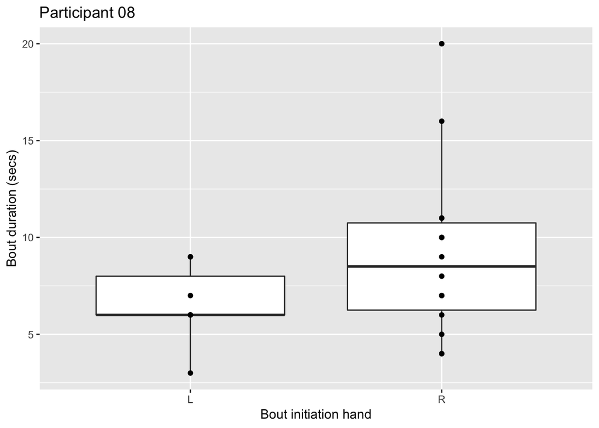

```r
crawl_init %>%
  ggplot() +
  aes(x = hand, y = duration) +
  geom_boxplot() +
  geom_point() +
  xlab('Bout initiation hand') +
  ylab('Bout duration (secs)') +
  ggtitle('Participant 08')
```